# Assignment 1 - Map and count

Biancamaria Florenzi, r0777934

Reference literature: Ma, H., Cao, L., Wang, F., Cheng, C., Jiang, R., Zhou, H., Xie, Z., Wuermanbieke, S., Qian, Z."Filamin B extensively regulates transcription and alternative splicing, and is associated with apoptosis in HeLa cells". Oncology Reports 43, no. 5 (2020): 1536-1546. https://doi.org/10.3892/or.2020.7532

Filamin B is an actin binding protein (ABP); in the study, RNA sequencing was used to analyse changes in the overall transcription between two conditions: HeLa control cells, and Filamin B knocked-down cells. Experimentally, it was previously shown that low expression levels of Filamin B are correlated with low cellular apoptosis; the hypothesis is that Filamin B regulates the expression of genes involved in cell appoptosis, tumor genesis and metastases in cancer cells.

```bash
mkdir -p /mnt/storage/$USER/jupyternotebooks/Assignment_1
cd /mnt/storage/$USER/jupyternotebooks/Assignment_1
vdb-config -s /repository/user/cache-disabled=true
```

## Retrieving the fastq files from SRA

I then renamed the files to FLNB and ctrl to more easily distinguish the two conditions.

```bash
#fastq-dump --split-files -X 5 -Z SRX6579264
fastq-dump --split-files SRX6579264
```

```
Read 39137830 spots for SRX6579264
Written 39137830 spots for SRX6579264
```

```bash
wc -l SRX6579264_1.fastq
wc -l SRX6579264_2.fastq #39137830 corresponds to the number of spots
```

```
156551320 SRX6579264_1.fastq
156551320 SRX6579264_2.fastq
```

```bash
fastq-dump --split-files SRX6579265 #number of spots corresponds
```

```
Read 36523323 spots for SRX6579265
Written 36523323 spots for SRX6579265
```

```bash
#head SRX6579265_1.fastq
wc -l SRX6579265_1.fastq
wc -l SRX6579265_2.fastq
```

[output not shown]

```bash
mv SRX6579265_1.fastq ctrl2_1.fastq
mv SRX6579265_2.fastq ctrl2_2.fastq
```

```bash
mv SRX6579264_1.fastq ctrl1_1.fastq
mv SRX6579264_2.fastq ctrl1_2.fastq
```

```bash
fastq-dump --split-files SRX6579266
```

```
2020-10-21T09:52:30 fastq-dump.2.9.6 sys: timeout exhausted while reading file within network system module - mbedtls_ssl_read returned -76 ( NET - Reading information from the socket failed )
2020-10-21T10:51:46 fastq-dump.2.9.6 sys: timeout exhausted while reading file within network system module - mbedtls_ssl_read returned -76 ( NET - Reading information from the socket failed )
2020-10-21T11:06:35 fastq-dump.2.9.6 sys: timeout exhausted while reading file within network system module - mbedtls_ssl_read returned -76 ( NET - Reading information from the socket failed )
2020-10-21T11:11:41 fastq-dump.2.9.6 sys: timeout exhausted while reading file within network system module - mbedtls_ssl_read returned -76 ( NET - Reading information from the socket failed )
2020-10-21T13:15:44 fastq-dump.2.9.6 sys: timeout exhausted while reading file within network system module - mbedtls_ssl_read returned -76 ( NET - Reading information from the socket failed )
Read 41385725 spots for SRX6579266
Written 41385725 spots for SRX6579266
```

```bash
wc -l SRX6579266_1.fastq #41,385,725 corresponds to the number of spots
```

```
165542900 SRX6579266_1.fastq
```

```bash
mv SRX6579266_1.fastq FLNB1_1.fastq
mv SRX6579266_2.fastq FLNB1_2.fastq
```

```bash
fastq-dump --split-files SRX6579267 #45200647 number of spots corresponds
```

[output not shown]

```bash
mv SRX6579267_1.fastq FLNB2_1.fastq
mv SRX6579267_2.fastq FLNB2_2.fastq
```

## Quality control with fastQC

I start by performing a quality control on the fastq files using fastqc and go through some interesting elements. The images are mostly taken by the analysis of the forward control sample 1, even though obviously all the fastqc reports have been analysed and compared.

```bash
/usr/bin/fastqc -o . *.fastq
```

```
Started analysis of ctrl1_1.fastq
Approx 5% complete for ctrl1_1.fastq
Approx 10% complete for ctrl1_1.fastq
Approx 15% complete for ctrl1_1.fastq
Approx 20% complete for ctrl1_1.fastq
Approx 25% complete for ctrl1_1.fastq
Approx 30% complete for ctrl1_1.fastq
Approx 35% complete for ctrl1_1.fastq
Approx 40% complete for ctrl1_1.fastq
Approx 45% complete for ctrl1_1.fastq
Approx 50% complete for ctrl1_1.fastq
Approx 55% complete for ctrl1_1.fastq
Approx 60% complete for ctrl1_1.fastq
Approx 65% complete for ctrl1_1.fastq
Approx 70% complete for ctrl1_1.fastq
Approx 75% complete for ctrl1_1.fastq
Approx 80% complete for ctrl1_1.fastq
Approx 85% complete for ctrl1_1.fastq
Approx 90% complete for ctrl1_1.fastq
Approx 95% complete for ctrl1_1.fastq
Analysis complete for ctrl1_1.fastq
Started analysis of ctrl1_2.fastq
Approx 5% complete for ctrl1_2.fastq
Approx 10% complete for ctrl1_2.fastq
Approx 15% complete for ctrl1_2.fastq
Approx 20% complete for ctrl1_2.fastq
Approx 25% complete for ctrl1_2.fastq
Approx 30% complete for ctrl1_2.fastq
Approx 35% complete for ctrl1_2.fastq
Approx 40% complete for ctrl1_2.fastq
Approx 45% complete for ctrl1_2.fastq
Approx 50% complete for ctrl1_2.fastq
Approx 55% complete for ctrl1_2.fastq
Approx 60% complete for ctrl1_2.fastq
Approx 65% complete for ctrl1_2.fastq
Approx 70% complete for ctrl1_2.fastq
Approx 75% complete for ctrl1_2.fastq
Approx 80% complete for ctrl1_2.fastq
Approx 85% complete for ctrl1_2.fastq
Approx 90% complete for ctrl1_2.fastq
```

[output cut: 113 more lines]

```
Approx 30% complete for FLNB2_2.fastq
Approx 35% complete for FLNB2_2.fastq
Approx 40% complete for FLNB2_2.fastq
Approx 45% complete for FLNB2_2.fastq
Approx 50% complete for FLNB2_2.fastq
Approx 55% complete for FLNB2_2.fastq
Approx 60% complete for FLNB2_2.fastq
Approx 65% complete for FLNB2_2.fastq
Approx 70% complete for FLNB2_2.fastq
Approx 75% complete for FLNB2_2.fastq
Approx 80% complete for FLNB2_2.fastq
Approx 85% complete for FLNB2_2.fastq
Approx 90% complete for FLNB2_2.fastq
Approx 95% complete for FLNB2_2.fastq
Analysis complete for FLNB2_2.fastq
```

The output is a serie of html files that contain information about the fastq files. For instance, the summary of the first control sample is shown here:

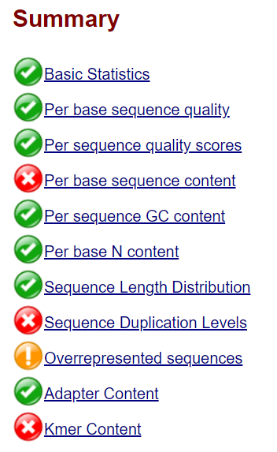

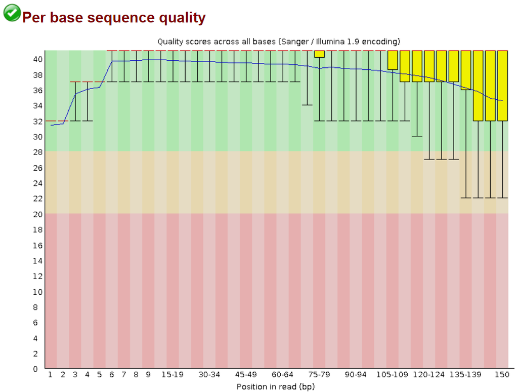

The Per Base Sequence content is flagged in red in all the reports, but I see that in approximately the first 10 base pairs the sequence content is unstable, but then it stabilises, which is quite normal for this type of data.

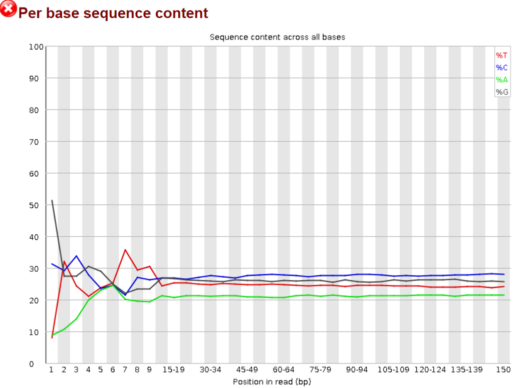

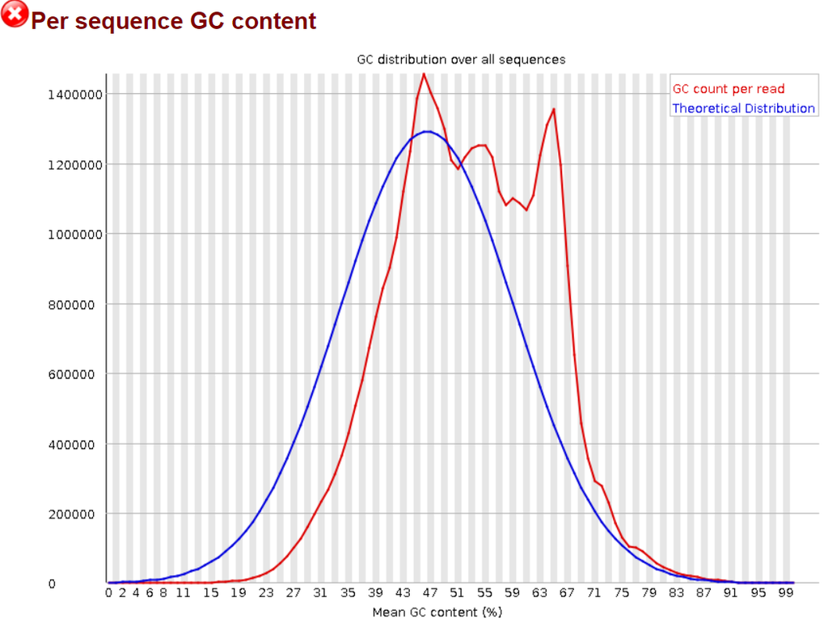

As for the overrepresented sequences, we have an orange tag, which would indicate a reasonable quality. This section is useful for pinpoint possible contaminations or an excessive presence of adapters or primers that were added during the sequencing.

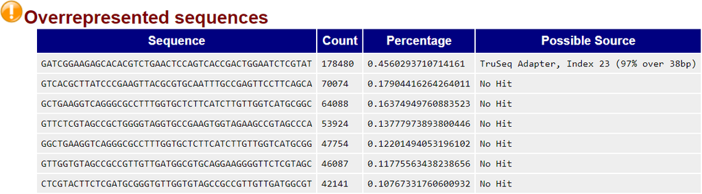

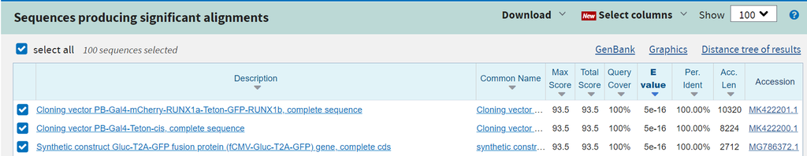

## Trimming with Trimmomatic

The quality of the files seems to be good enough; however I think that the percentage for the presence of overrepresented sequences could be lower, and additionally I know that during the analysis in the reference literature a trimming has been performed. Therefore I decide to trim the adapters from the fastqfiles, and I do so by using trimmomatic, which I have manually uploaded as zip file to the folder in its 0.36 version (after a first attempt with wget).

```bash
echo $PWD
ls *.fastq
```

```
/mnt/storage/r0777934/jupyternotebooks/Assignment_1
ctrl1_1.fastq  ctrl2_1.fastq  FLNB1_1.fastq  FLNB2_1.fastq
ctrl1_2.fastq  ctrl2_2.fastq  FLNB1_2.fastq  FLNB2_2.fastq
```

```bash
#wget http://www.usadellab.org/cms/uploads/supplementary/Trimmomatic/Trimmomatic-0.36.zip
unzip Trimmomatic-0.36.zip
```

```
Archive:  Trimmomatic-0.36.zip
   creating: Trimmomatic-0.36/
  inflating: Trimmomatic-0.36/LICENSE
  inflating: Trimmomatic-0.36/trimmomatic-0.36.jar
   creating: Trimmomatic-0.36/adapters/
  inflating: Trimmomatic-0.36/adapters/NexteraPE-PE.fa
  inflating: Trimmomatic-0.36/adapters/TruSeq2-PE.fa
  inflating: Trimmomatic-0.36/adapters/TruSeq2-SE.fa
  inflating: Trimmomatic-0.36/adapters/TruSeq3-PE-2.fa
  inflating: Trimmomatic-0.36/adapters/TruSeq3-PE.fa
  inflating: Trimmomatic-0.36/adapters/TruSeq3-SE.fa
```

With Trimmomatic I perform a paired end (PE) trimming; the phred33 refers to the Sanger format that is used for sequencing starting from Illumina 1.8 and that should therefore be applied in this case as well. The trimming tool requires the forward and backward fastq files as input and will output four files, for the unparied and the paired reads. It will be enough for us to use the paired reads for subsequent mapping. The ILLUMINACLIP option is for the trimming of the adapters, whose reference sequences for alignment and comparison are provided with the tool itself (adapters/PE/TruSeq3). The rest of the options are quite standard and suggested by the tool provider itself for a soft quality trimming:

- Remove leading low quality or N bases below quality 3 (LEADING:3)
- Remove trailing low quality or N bases below quality 3 (TRAILING:3)
- Scan the read with a 4-base wide sliding window, cutting when the average quality per base drops below 15 (SLIDINGWINDOW:4:15)
- Drop reads below the 36 bases long (MINLEN:36)

```bash
java -jar /mnt/storage/r0777934/jupyternotebooks/Assignment_1/Trimmomatic-0.36/trimmomatic-0.36.jar \
PE -phred33 \
ctrl1_1.fastq \
ctrl1_2.fastq \
output_ctrl1_1_paired.fq.gz \
output_ctrl1_1_unpaired.fq.gz \
output_ctrl1_2_paired.fq.gz \
output_ctrl1_2_unpaired.fq.gz \
ILLUMINACLIP:../Trimmomatic-0.36/adapters/TruSeq3-PE.fa:2:30:10:2:keepBothReads \
LEADING:3 \
TRAILING:3 \
SLIDINGWINDOW:4:15 \
MINLEN:36
```

[output not shown]

```bash
java -jar /mnt/storage/r0777934/jupyternotebooks/Assignment_1/Trimmomatic-0.36/trimmomatic-0.36.jar \
PE -phred33 \
ctrl2_1.fastq \
ctrl2_2.fastq \
output_ctrl2_1_paired.fq.gz \
output_ctrl2_1_unpaired.fq.gz \
output_ctrl2_2_paired.fq.gz \
output_ctrl2_2_unpaired.fq.gz \
ILLUMINACLIP:../Trimmomatic-0.36/adapters/TruSeq3-PE.fa:2:30:10:2:keepBothReads \
LEADING:3 \
TRAILING:3 \
SLIDINGWINDOW:4:15 \
MINLEN:36
```

[output not shown]

```bash
java -jar /mnt/storage/r0777934/jupyternotebooks/Assignment_1/Trimmomatic-0.36/trimmomatic-0.36.jar \
PE -phred33 \
FLNB1_1.fastq \
FLNB1_2.fastq \
output_FLNB1_1_paired.fq.gz \
output_FLNB1_1_unpaired.fq.gz \
output_FLNB1_2_paired.fq.gz \
output_FLNB1_2_unpaired.fq.gz \
ILLUMINACLIP:../Trimmomatic-0.36/adapters/TruSeq3-PE.fa:2:30:10:2:keepBothReads \
LEADING:3 \
TRAILING:3 \
SLIDINGWINDOW:4:15 \
MINLEN:36
```

```bash
java -jar /mnt/storage/r0777934/jupyternotebooks/Assignment_1/Trimmomatic-0.36/trimmomatic-0.36.jar \
PE -phred33 \
FLNB2_1.fastq \
FLNB2_2.fastq \
output_FLNB2_1_paired.fq.gz \
output_FLNB2_1_unpaired.fq.gz \
output_FLNB2_2_paired.fq.gz \
output_FLNB2_2_unpaired.fq.gz \
ILLUMINACLIP:../Trimmomatic-0.36/adapters/TruSeq3-PE.fa:2:30:10:2:keepBothReads \
LEADING:3 \
TRAILING:3 \
SLIDINGWINDOW:4:15 \
MINLEN:36
```

```bash
ls output_*.fq.gz
```

```
output_ctrl1_1_paired.fq.gz    output_FLNB1_1_paired.fq.gz
output_ctrl1_1_unpaired.fq.gz  output_FLNB1_1_unpaired.fq.gz
output_ctrl1_2_paired.fq.gz    output_FLNB1_2_paired.fq.gz
output_ctrl1_2_unpaired.fq.gz  output_FLNB1_2_unpaired.fq.gz
output_ctrl2_1_paired.fq.gz    output_FLNB2_1_paired.fq.gz
output_ctrl2_1_unpaired.fq.gz  output_FLNB2_1_unpaired.fq.gz
output_ctrl2_2_paired.fq.gz    output_FLNB2_2_paired.fq.gz
output_ctrl2_2_unpaired.fq.gz  output_FLNB2_2_unpaired.fq.gz
```

The ouput files are in a compressed version of fastq, gzip. I can feed these directly to fastqc for a second quality analysis on the reads.

```bash
/usr/bin/fastqc -o . output_*_paired.fq.gz
```

```
Started analysis of output_ctrl1_1_paired.fq.gz
Approx 5% complete for output_ctrl1_1_paired.fq.gz
Approx 10% complete for output_ctrl1_1_paired.fq.gz
Approx 15% complete for output_ctrl1_1_paired.fq.gz
Approx 20% complete for output_ctrl1_1_paired.fq.gz
Approx 25% complete for output_ctrl1_1_paired.fq.gz
Approx 30% complete for output_ctrl1_1_paired.fq.gz
Approx 35% complete for output_ctrl1_1_paired.fq.gz
Approx 40% complete for output_ctrl1_1_paired.fq.gz
Approx 45% complete for output_ctrl1_1_paired.fq.gz
Approx 50% complete for output_ctrl1_1_paired.fq.gz
Approx 55% complete for output_ctrl1_1_paired.fq.gz
Approx 60% complete for output_ctrl1_1_paired.fq.gz
Approx 65% complete for output_ctrl1_1_paired.fq.gz
Approx 70% complete for output_ctrl1_1_paired.fq.gz
Approx 75% complete for output_ctrl1_1_paired.fq.gz
Approx 80% complete for output_ctrl1_1_paired.fq.gz
Approx 85% complete for output_ctrl1_1_paired.fq.gz
Approx 90% complete for output_ctrl1_1_paired.fq.gz
Approx 95% complete for output_ctrl1_1_paired.fq.gz
Analysis complete for output_ctrl1_1_paired.fq.gz
Started analysis of output_ctrl1_2_paired.fq.gz
Approx 5% complete for output_ctrl1_2_paired.fq.gz
Approx 10% complete for output_ctrl1_2_paired.fq.gz
Approx 15% complete for output_ctrl1_2_paired.fq.gz
Approx 20% complete for output_ctrl1_2_paired.fq.gz
Approx 25% complete for output_ctrl1_2_paired.fq.gz
Approx 30% complete for output_ctrl1_2_paired.fq.gz
Approx 35% complete for output_ctrl1_2_paired.fq.gz
Approx 40% complete for output_ctrl1_2_paired.fq.gz
Approx 45% complete for output_ctrl1_2_paired.fq.gz
Approx 50% complete for output_ctrl1_2_paired.fq.gz
Approx 55% complete for output_ctrl1_2_paired.fq.gz
Approx 60% complete for output_ctrl1_2_paired.fq.gz
Approx 65% complete for output_ctrl1_2_paired.fq.gz
Approx 70% complete for output_ctrl1_2_paired.fq.gz
Approx 75% complete for output_ctrl1_2_paired.fq.gz
Approx 80% complete for output_ctrl1_2_paired.fq.gz
Approx 85% complete for output_ctrl1_2_paired.fq.gz
Approx 90% complete for output_ctrl1_2_paired.fq.gz
```

[output cut: 113 more lines]

```
Approx 30% complete for output_FLNB2_2_paired.fq.gz
Approx 35% complete for output_FLNB2_2_paired.fq.gz
Approx 40% complete for output_FLNB2_2_paired.fq.gz
Approx 45% complete for output_FLNB2_2_paired.fq.gz
Approx 50% complete for output_FLNB2_2_paired.fq.gz
Approx 55% complete for output_FLNB2_2_paired.fq.gz
Approx 60% complete for output_FLNB2_2_paired.fq.gz
Approx 65% complete for output_FLNB2_2_paired.fq.gz
Approx 70% complete for output_FLNB2_2_paired.fq.gz
Approx 75% complete for output_FLNB2_2_paired.fq.gz
Approx 80% complete for output_FLNB2_2_paired.fq.gz
Approx 85% complete for output_FLNB2_2_paired.fq.gz
Approx 90% complete for output_FLNB2_2_paired.fq.gz
Approx 95% complete for output_FLNB2_2_paired.fq.gz
Analysis complete for output_FLNB2_2_paired.fq.gz
```

```bash
gzip -d output_*_paired.fq.gz
```

Even though even after trimming some overrepresented sequences are still present, their presence has been significantly reduced by the trimming and is no higher than 0,5%; I have excluded that some of these might be caused by a specific contamination by BLASTing some of the overrepresented sequences and finding that they did not correspond to e.g. all to some other specific organism. The relevant sections of the fastqc analysis still show good results, and therefore I decide to proceed with the mapping and the analysis and accepting the samples.

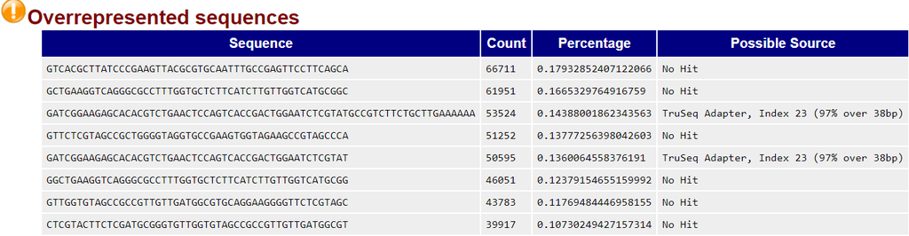

In the trimmed quality analysis, we see an additional orange tag for the sequence lenght distribution given by the fact that we have performed the trimming, and therefore we do not have the classical tringle-shaped distribution that we previously had for the untrimmed reads.

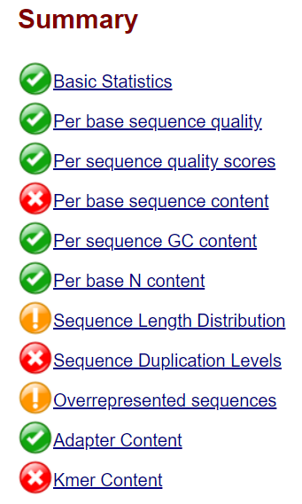

## Mapping to the genome with STAR

The mapping has been performed first on the untrimmed fastq files for comparison, but then the alignment for the trimmed files has been then used for further analyses (this is because I first had decided not to perform trimming on the files and carried out subsequent analyses on the untrimmed files, but later decided to go back and perform better tuning on the alignment).

```bash
#ls /mnt/nfs/mfiers/STAR/
```

```bash
STAR --genomeDir /mnt/nfs/mfiers/STAR/hg19_star_db \
     --genomeLoad NoSharedMemory \
     --runThreadN 2 \
     --readFilesIn  ctrl1_1.fastq ctrl1_2.fastq\
     --outFileNamePrefix ctrl1.
```

```
Nov 05 09:54:53 ..... started STAR run
Nov 05 09:54:53 ..... loading genome
Nov 05 09:55:57 ..... started mapping
Nov 05 11:47:26 ..... finished successfully
```

```bash
STAR --genomeDir /mnt/nfs/mfiers/STAR/hg19_star_db \
     --genomeLoad NoSharedMemory \
     --runThreadN 2 \
     --readFilesIn  ctrl2_1.fastq ctrl2_2.fastq\
     --outFileNamePrefix ctrl2.
```

```
Nov 05 11:55:12 ..... started STAR run
Nov 05 11:55:12 ..... loading genome
Nov 05 11:56:15 ..... started mapping
Nov 05 13:27:38 ..... finished successfully
```

```bash
STAR --genomeDir /mnt/nfs/mfiers/STAR/hg19_star_db \
     --genomeLoad NoSharedMemory \
     --runThreadN 2 \
     --readFilesIn  FLNB1_1.fastq FLNB1_2.fastq\
     --outFileNamePrefix FLNB1.
```

```
Nov 05 16:24:02 ..... started STAR run
Nov 05 16:24:02 ..... loading genome
Nov 05 16:24:24 ..... started mapping
Nov 05 18:07:51 ..... finished successfully
```

```bash
STAR --genomeDir /mnt/nfs/mfiers/STAR/hg19_star_db \
     --genomeLoad NoSharedMemory \
     --runThreadN 2 \
     --readFilesIn  FLNB2_1.fastq FLNB2_2.fastq\
     --outFileNamePrefix FLNB2.
```

```
Nov 05 18:16:28 ..... started STAR run
Nov 05 18:16:28 ..... loading genome
Nov 05 18:17:10 ..... started mapping
Nov 05 20:13:49 ..... finished successfully
```

```bash
ls ctrl1.*
```

```
ctrl1.Aligned.out.sam  ctrl1.Log.out           ctrl1.SJ.out.tab
ctrl1.Log.final.out    ctrl1.Log.progress.out
```

### Alignment for the trimmed fastq files

```bash
ls output_*_paired.fq
```

```
output_ctrl1_1_paired.fq  output_ctrl2_2_paired.fq  output_FLNB2_1_paired.fq
output_ctrl1_2_paired.fq  output_FLNB1_1_paired.fq  output_FLNB2_2_paired.fq
output_ctrl2_1_paired.fq  output_FLNB1_2_paired.fq
```

```bash
STAR --genomeDir /mnt/nfs/mfiers/STAR/hg19_star_db \
     --genomeLoad NoSharedMemory \
     --runThreadN 2 \
     --readFilesIn  output_ctrl1_1_paired.fq output_ctrl1_2_paired.fq \
     --outFileNamePrefix trimmed_ctrl1.
```

```
Nov 19 10:46:16 ..... started STAR run
Nov 19 10:46:16 ..... loading genome
Nov 19 10:47:05 ..... started mapping
Nov 19 12:14:42 ..... finished successfully
```

```bash
STAR --genomeDir /mnt/nfs/mfiers/STAR/hg19_star_db \
     --genomeLoad NoSharedMemory \
     --runThreadN 2 \
     --readFilesIn  output_ctrl2_1_paired.fq output_ctrl2_2_paired.fq \
     --outFileNamePrefix trimmed_ctrl2.
```

```
Nov 19 14:14:46 ..... started STAR run
Nov 19 14:14:46 ..... loading genome
Nov 19 14:15:27 ..... started mapping
Nov 19 15:31:43 ..... finished successfully
```

```bash
STAR --genomeDir /mnt/nfs/mfiers/STAR/hg19_star_db \
     --genomeLoad NoSharedMemory \
     --runThreadN 2 \
     --readFilesIn  output_FLNB1_1_paired.fq output_FLNB1_2_paired.fq \
     --outFileNamePrefix trimmed_FLNB1.
```

```
Nov 19 15:43:21 ..... started STAR run
Nov 19 15:43:21 ..... loading genome
Nov 19 15:43:39 ..... started mapping
Nov 19 17:06:03 ..... finished successfully
```

```bash
STAR --genomeDir /mnt/nfs/mfiers/STAR/hg19_star_db \
     --genomeLoad NoSharedMemory \
     --runThreadN 2 \
     --readFilesIn  output_FLNB2_1_paired.fq output_FLNB2_2_paired.fq \
     --outFileNamePrefix trimmed_FLNB2.
```

```
Nov 19 18:32:20 ..... started STAR run
Nov 19 18:32:20 ..... loading genome
Nov 19 18:33:10 ..... started mapping
Nov 19 20:06:16 ..... finished successfully
```

```bash
ls trimmed_*.sam
```

```
trimmed_ctrl1.Aligned.out.sam  trimmed_FLNB1.Aligned.out.sam
trimmed_ctrl2.Aligned.out.sam  trimmed_FLNB2.Aligned.out.sam
```

The alignment output files are inspected and report a successful alignment of around 70% of the reads, which is still an acceptable percentage for a DE analysis.

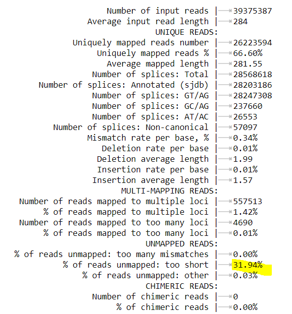

## From SAM to BAM files

Create bam files and index them with samtools.

```bash
samtools sort -o trimmed_ctrl1.bam trimmed_ctrl1.Aligned.out.sam
samtools sort -o trimmed_ctrl2.bam trimmed_ctrl2.Aligned.out.sam
samtools sort -o trimmed_FLNB1.bam trimmed_FLNB1.Aligned.out.sam
samtools sort -o trimmed_FLNB2.bam trimmed_FLNB2.Aligned.out.sam
```

```
[bam_sort_core] merging from 19 files and 1 in-memory blocks...
[bam_sort_core] merging from 19 files and 1 in-memory blocks...
[bam_sort_core] merging from 22 files and 1 in-memory blocks...
[bam_sort_core] merging from 23 files and 1 in-memory blocks...
```

```bash
ls trimmed_*.bam.bai
```

[output not shown]

```bash
samtools index trimmed_ctrl1.bam
samtools index trimmed_ctrl2.bam
samtools index trimmed_FLNB1.bam
samtools index trimmed_FLNB2.bam
```

```bash
samtools flagstat trimmed_ctrl1.bam
```

```
46769059 + 0 in total (QC-passed reads + QC-failed reads)
1289736 + 0 secondary
0 + 0 supplementary
0 + 0 duplicates
46769059 + 0 mapped (100.00% : N/A)
45479323 + 0 paired in sequencing
22759450 + 0 read1
22719873 + 0 read2
45432346 + 0 properly paired (99.90% : N/A)
45432346 + 0 with itself and mate mapped
46977 + 0 singletons (0.10% : N/A)
0 + 0 with mate mapped to a different chr
0 + 0 with mate mapped to a different chr (mapQ>=5)
```

```bash
samtools idxstats trimmed_ctrl1.bam
```

```
chrM	16571	982726	0
chr1	249250621	4816488	0
chr2	243199373	2346353	0
chr3	198022430	2107777	0
chr4	191154276	589223	0
chr5	180915260	2054210	0
chr6	171115067	2398464	0
chr7	159138663	2299763	0
chr8	146364022	1468102	0
chr9	141213431	2024958	0
chr10	135534747	1302078	0
chr11	135006516	3370011	0
chr12	133851895	3709250	0
chr13	115169878	385053	0
chr14	107349540	852242	0
chr15	102531392	1431881	0
chr16	90354753	2797097	0
chr17	81195210	3133241	0
chr18	78077248	259998	0
chr19	59128983	3022960	0
chr20	63025520	1233100	0
chr21	48129895	1085455	0
chr22	51304566	948717	0
chrX	155270560	2109949	0
chrY	59373566	39963	0
*	0	0	0
```

The inspection of the bam files with flagstat and idxstat do not seem to reveal any problems in the alignment. These bam files can be visualised in IGV, and some of the relevant genes can be shown. Above is the control 1 sample (in blue) and below the Filamin B knockdown sample 1 (in red); the scaling has been set to equal values in order to be comparable.

The gene MALAT1 is a gene that is differentially expressed in the two conditions and that is associated with cancers like leukemia (Metastasis Associated Lung Adenocarcinoma Transcript 1).

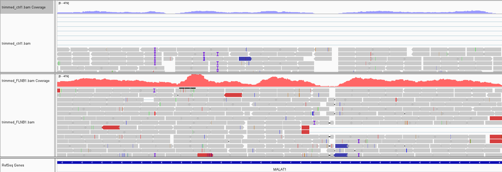

NAIP on chromosome 5 is a low expressed gene whose expression is increased in the Filamin B knocked down (Neuronal Apoptosis Inhibitory Protein); it is one of the target genes more relevant in the reference literature, as its overexpression in the second condition is in line with the initial hypothesis of the study.

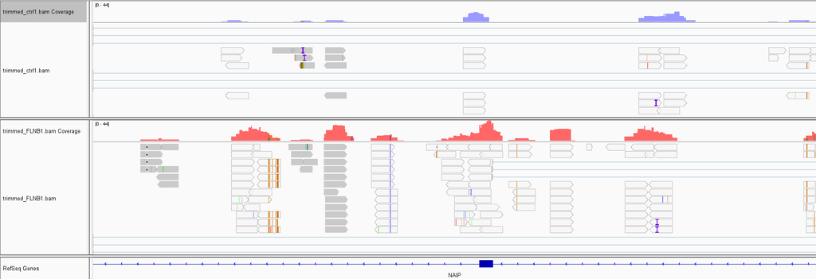

MMP13, which is fundamental for skeletal development, on chromosome 11 is not expressed in the control, and expressed in the filamin knockdown.

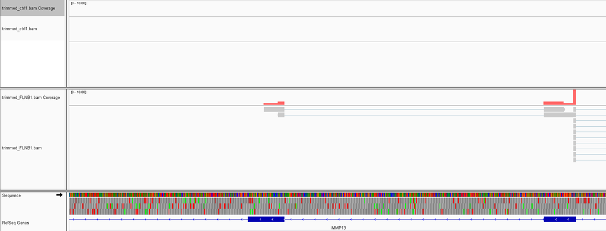

## Perform counting with FeatureCounts

```bash
ln -sf /mnt/nfs/data/RNA-seq/gencode.v19.nopseudo.plus.sort.gtf
ls -l *gtf
head *gtf
```

```
lrwxrwxrwx 1 r0777934 domain users 56 Nov  7 18:23 gencode.v19.nopseudo.plus.sort.gtf -> /mnt/nfs/data/RNA-seq/gencode.v19.nopseudo.plus.sort.gtf
##description: evidence-based annotation of the human genome (GRCh37), version 19 (Ensembl 74)
##provider: GENCODE
##contact: gencode@sanger.ac.uk
##format: gtf
##date: 2013-12-05
chr1	HAVANA	exon	29554	30039	.	+	.	gene_id "ENSG00000243485.2"; transcript_id "ENST00000473358.1"; gene_type "lincRNA"; gene_status "NOVEL"; gene_name "MIR1302-11"; transcript_type "lincRNA"; transcript_status "KNOWN"; transcript_name "MIR1302-11-001"; exon_number 1;  exon_id "ENSE00001947070.1";  l…
chr1	HAVANA	gene	29554	31109	.	+	.	gene_id "ENSG00000243485.2"; transcript_id "ENSG00000243485.2"; gene_type "lincRNA"; gene_status "NOVEL"; gene_name "MIR1302-11"; transcript_type "lincRNA"; transcript_status "NOVEL"; transcript_name "MIR1302-11"; level 2; havana_gene "OTTHUMG00000000959.2";
chr1	HAVANA	transcript	29554	31097	.	+	.	gene_id "ENSG00000243485.2"; transcript_id "ENST00000473358.1"; gene_type "lincRNA"; gene_status "NOVEL"; gene_name "MIR1302-11"; transcript_type "lincRNA"; transcript_status "KNOWN"; transcript_name "MIR1302-11-001"; level 2; tag "not_best_in_genome_evidence…
chr1	HAVANA	exon	30267	30667	.	+	.	gene_id "ENSG00000243485.2"; transcript_id "ENST00000469289.1"; gene_type "lincRNA"; gene_status "NOVEL"; gene_name "MIR1302-11"; transcript_type "lincRNA"; transcript_status "KNOWN"; transcript_name "MIR1302-11-002"; exon_number 1;  exon_id "ENSE00001841699.1";  l…
chr1	HAVANA	transcript	30267	31109	.	+	.	gene_id "ENSG00000243485.2"; transcript_id "ENST00000469289.1"; gene_type "lincRNA"; gene_status "NOVEL"; gene_name "MIR1302-11"; transcript_type "lincRNA"; transcript_status "KNOWN"; transcript_name "MIR1302-11-002"; level 2; tag "not_best_in_genome_evidence…
```

```bash
featureCounts \
    -Q 10 \
    -g gene_name \
    -a /mnt/nfs/data/RNA-seq/gencode.v19.nopseudo.plus.sort.gtf \
    -o all.trimmed.counts \
    trimmed_ctrl1.bam trimmed_ctrl2.bam trimmed_FLNB1.bam trimmed_FLNB2.bam
```

```
        ==========     _____ _    _ ____  _____  ______          _____
        =====         / ____| |  | |  _ \|  __ \|  ____|   /\   |  __ \
          =====      | (___ | |  | | |_) | |__) | |__     /  \  | |  | |
            ====      \___ \| |  | |  _ <|  _  /|  __|   / /\ \ | |  | |
              ====    ____) | |__| | |_) | | \ \| |____ / ____ \| |__| |
        ==========   |_____/ \____/|____/|_|  \_\______/_/    \_\_____/
	  v1.6.0

//========================== featureCounts setting ===========================\\
||                                                                            ||
||             Input files : 4 BAM files                                      ||
||                           P trimmed_ctrl1.bam                              ||
||                           P trimmed_ctrl2.bam                              ||
||                           P trimmed_FLNB1.bam                              ||
||                           P trimmed_FLNB2.bam                              ||
||                                                                            ||
||             Output file : all.trimmed.counts                               ||
||                 Summary : all.trimmed.counts.summary                       ||
||              Annotation : /mnt/nfs/data/RNA-seq/gencode.v19.nopseudo.p ... ||
||      Dir for temp files : ./                                               ||
||                                                                            ||
||                 Threads : 1                                                ||
||                   Level : meta-feature level                               ||
||              Paired-end : no                                               ||
||         Strand specific : no                                               ||
||      Multimapping reads : not counted                                      ||
|| Multi-overlapping reads : not counted                                      ||
||   Min overlapping bases : 1                                                ||
||                                                                            ||
\\===================== http://subread.sourceforge.net/ ======================//

//================================= Running ==================================\\
||                                                                            ||
|| Load annotation file /mnt/nfs/data/RNA-seq/gencode.v19.nopseudo.plus.s ... ||
||    Features : 1156385                                                      ||
||    Meta-features : 41863                                                   ||
||    Chromosomes/contigs : 25                                                ||
||                                                                            ||
|| Process BAM file trimmed_ctrl1.bam...                                      ||
||    Paired-end reads are included.                                          ||
```

[output cut: 17 more lines]

```
||    Running time : 1.09 minutes                                             ||
||                                                                            ||
|| Process BAM file trimmed_FLNB2.bam...                                      ||
||    Paired-end reads are included.                                          ||
||    Assign reads to features...                                             ||
||    Total reads : 57869846                                                  ||
||    Successfully assigned reads : 45104622 (77.9%)                          ||
||    Running time : 1.16 minutes                                             ||
||                                                                            ||
||                         Read assignment finished.                          ||
||                                                                            ||
|| Summary of counting results can be found in file "all.trimmed.counts.summ  ||
|| ary"                                                                       ||
||                                                                            ||
\\===================== http://subread.sourceforge.net/ ======================//
```

```bash
cut -f-6 all.trimmed.counts > all.trimmed.genedata.tsv
```

```bash
cut -f1,7- all.trimmed.counts | grep -v '^#' > all.trimmed.gene.counts
```

```bash
wc -l all.trimmed.gene.counts
```

```
41864 all.trimmed.gene.counts
```

```bash
grep NAIP all.trimmed.gene.counts
grep MALAT1 all.trimmed.gene.counts
grep MMP13 all.trimmed.gene.counts
```

```
NAIP	6	68	189	50
MALAT1	2611	2374	10443	7416
MMP13	0	0	26	62
```